# Using `lubridate` to Work with Dates

## Wednesday April 29th

Today we will…

- Midterm Exam - What to expect
- New Material
  - Working with Date & Time Variables
- PA 5.2: Jewel Heist

# Midterm Info

## Midterm Exam - Wed 5/6

- This is a two-part exam completed in the one hour and 50 minute class period
  1. You will first complete a **General Questions** section **on paper** and **without your computer**.
  2. After you turn that in, you will complete a **Short Answer** section **with your computer**.

## Midterm Exam - Wed 5/6

- Review the “What to Expect” document thoroughly as it includes
  - detailed expectations
  - the dataset you will be working with
- Set yourself up with a dedicated directory that has the data in it
- Make sure to bring to the exam:
  - something to write with (black/blue pen or pencils)
  - your laptop (& a charging chord)

## Midterm - Coding Portion

- You may use course and online resources other but **not generative AI**
- All questions can be addressed with just the course materials
  - this includes cheatsheets, course slides, or course assignments (anything linked through the course materials page or Canvas)
- You must **cite** any resources that are not the course materials
  - include the *prompt* for Google searchers
- I expect what you submit is **your** work

**Caution**

While the coding tasks allow resources, you will likely run out of time if you have to look everything up. Know what functions you might need and where to find documentation for implementing these functions.

## Midterm Preparation Suggestions

- Review course slides, handouts, & Quizzes
- Quiz each other on the uses of different functions
- Try to re-do parts of the PAs or LAs from scratch
- Start working with the data
  - HAVE CODE SET UP THAT READS IN THE DATA
  - Ask some questions about the data and try to answer them
- Save example code for things you find tricky in a place you can find it
- **Get sleep and feed yourself!** 🛌🥞🥙🍛

## Midterm - Practice Gradescope Submission

- Rather than an .html to directly to Canvas, you will submit a rendered .pdf to Gradescope through Canvas
- Let’s make sure this works now!

# Date + Time Variables

## `lubridate`

- Convert a date-like variable (“May 8, 1995”) to a date or date-time object.
- Find the weekday, month, year, etc from a date-time object.
- Convert between time zones.

[figure not shown]

**Note**

The `lubridate` package **installs** and **loads** with the `tidyverse`.

## Why are dates and times tricky?

When parsing dates and times, we have to consider complicating factors like…

- Daylight Savings Time.
  - One day a year is 23 hours; one day a year is 25 hours.
  - Some places use it, some don’t.
- Leap years – most years have 365 days, some have 366.
- Time zones.

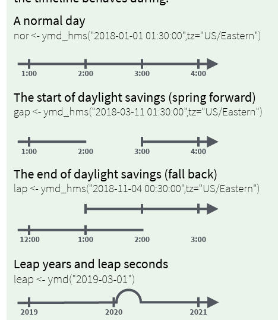

## Creating `date-time` Objects

**Big Picture**

There are a lot of diferent ways to create `date-time` objects!

Create a date from individual components:

```r
make_date(year = 1995, month = 05, day = 08)
```

```
[1] "1995-05-08"
```

Create a date from a number:

```r
dmy(08051995)
```

```
[1] "1995-05-08"
```

```r
ymd(19950508)
```

```
[1] "1995-05-08"
```

## Create a `date-time` Object from a String

```r
mdy("August 29, 1991")
```

```
[1] "1991-08-29"
```

```r
dmy("29-August-1991",
    tz = "America/Denver")
```

```
[1] "1991-08-29 MDT"
```

```r
dmy_hms("29-August-1991 9:32:12",
        tz = "America/Denver")
```

```
[1] "1991-08-29 09:32:12 MDT"
```

```r
as_datetime("91-08-29",
            format = "%y-%m-%d")
```

```
[1] "1991-08-29 UTC"
```

```r
parse_datetime("8/29/1991",
               format = "%m/%d/%Y")
```

```
[1] "1991-08-29 UTC"
```

## Creating `date-time` Objects

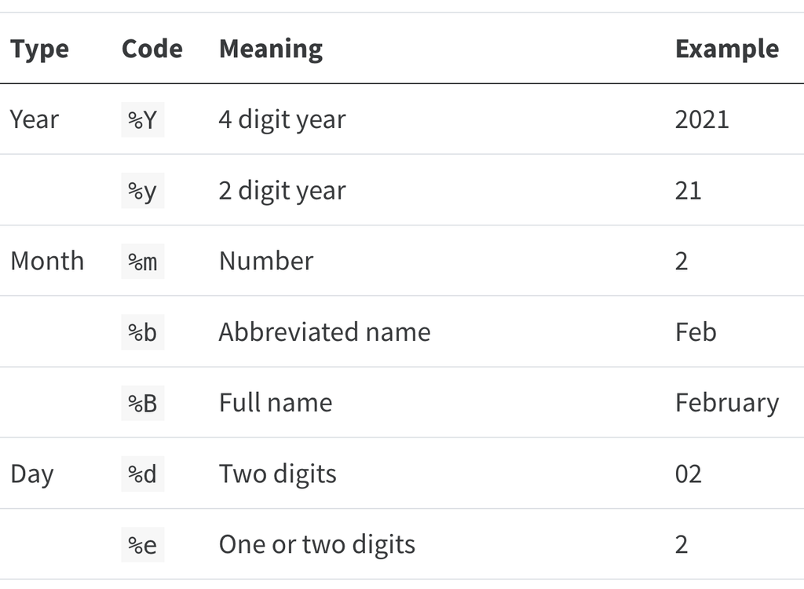

## Extracting `date-time` Components

```r
bday <- ymd_hms("1995-02-27 07:03:12",
                tz = "America/Chicago")
bday
```

```
[1] "1995-02-27 07:03:12 CST"
```

```r
year(bday)
```

```
[1] 1995
```

```r
month(bday)
```

```
[1] 2
```

```r
day(bday)
```

```
[1] 27
```

```r
wday(bday)
```

```
[1] 2
```

```r
wday(bday,
     label = TRUE,
     abbr = FALSE)
```

```
[1] Monday
7 Levels: Sunday < Monday < Tuesday < Wednesday < Thursday < ... < Saturday
```

## Subtraction with `date-time` Objects

Doing subtraction gives you a `difftime` object.

`difftime` objects do not always have the same units – it depends on the scale of the objects you are working with.

How old am I?

```r
today() - mdy("02-27-1995")
```

```
Time difference of 11397 days
```

How long did it take me to type this slide?

```r
begin <- mdy_hms("10/21/2024 20:40:34")
finish <- mdy_hms("10/21/2024 20:43:11")

finish - begin
```

```
Time difference of 2.616667 mins
```

## Durations and Periods

**Durations** will always give the time span in an **exact number of seconds**.

```r
as.duration(
  today() - mdy("02-27-1995")
            )
```

```
[1] "984700800s (~31.2 years)"
```

**Periods** will give the time span in more approximate, but **human readable times**.

```r
as.period(
  today() - mdy("02-27-1995")
  )
```

```
[1] "11397d 0H 0M 0S"
```

## Durations and Periods

We can also **add** time to `date-time` objects:

- `ddays()`, `dyears()`, etc. will add a **duration** of time.
- `days()`, `years()`, etc. will add a **period** of time.

Because durations use the **exact** number of seconds to represent days and years, you might get unexpected results.

When is is my 99th birthday?

```r
mdy("02/27/1995") + dyears(99)
```

```
[1] "2094-02-26 18:00:00 UTC"
```

```r
mdy("02/27/1995") + years(99)
```

```
[1] "2094-02-27"
```

## Intervals

Sppose Delta requires members to travel within 4 weeks before or after their birthday to earn a “Birthday Bonus Flight.”

Well, we first need to make an interval of time around my birthday.

```r
bday <- mdy("02-27-2026")

bonus_flight_window <- interval(
  bday - weeks(4),
  bday + weeks(4)
)
```

Then I can check if today is within this interval.

```r
today() %within% bonus_flight_window
```

```
[1] FALSE
```

## Time Zones…

…are complicated!

Time zones have specific values in lubridate. Most are specified as:

- {continent}/{city} – “America/Denver”, “Africa/Nairobi”
- {ocean}/{city} – “Pacific/Auckland” . . .

The US time-zones can be specified as:

- “US/Eastern”, “US/Central”, “US/Mountain”, and “US/Pacific”

What time zone does R think I’m in?

```r
Sys.timezone()
```

```
[1] "America/Los_Angeles"
```

## Time Zones

You can change the time zone of a date in two ways:

```r
x <- ymd_hms("2024-10-24 18:00:00",
             tz = "Europe/Copenhagen")
```

`with_tz()`

Keeps the instant in time the same, but changes the visual representation.

```r
x |>
  with_tz()
```

```
[1] "2024-10-24 09:00:00 PDT"
```

```r
x |>
  with_tz(tzone = "Asia/Kolkata")
```

```
[1] "2024-10-24 21:30:00 IST"
```

`force_tz()`

Changes the instant in time by forcing a time zone change.

```r
x |>
  force_tz()
```

```
[1] "2024-10-24 18:00:00 PDT"
```

```r
x |>
  force_tz(tzone = "Asia/Kolkata")
```

```
[1] "2024-10-24 18:00:00 IST"
```

## Common Mistake with Dates

When you read data in or create a new date-time object, the default time zone (if not specified) is UTC (Universal Time Coordinated)*.

So, make sure you specify your desired time zone!

```r
x <- mdy("11/20/1993")
tz(x)
```

```
[1] "UTC"
```

```r
x <- mdy("11/20/1993",
         tz = "America/Los_Angeles")
tz(x)
```

```
[1] "America/Los_Angeles"
```

*UTC is the same as GMT (Greenwich Mean Time) which is where Iceland is located

## Working with Dates in Data

- the `lubridate` functions take a **vector** as the first argument
- when working with data, we need to combine `lubridate` functions with `dplyr` verbs!

```r
dat
```

```
# A tibble: 3 × 2
  date       event
  <chr>      <chr>
1 05-04-2026 may the 4th be with you
2 05-01-2026 may day
3 06-01-2026 pride month
```

```r
dat |>
  mutate(date = mdy(date),
         month = month(date)
         )
```

```
# A tibble: 3 × 3
  date       event                   month
  <date>     <chr>                   <dbl>
1 2026-05-04 may the 4th be with you     5
2 2026-05-01 may day                     5
3 2026-06-01 pride month                 6
```

## Tips for Working with Dates

- Always just check that you are getting results that you expect!
- Pay attention to time zones
- Use the lubridate [cheatsheet](https://rstudio.github.io/cheatsheets/lubridate.pdf)

[figure not shown]

## PA 5.2: Jewel Heist

- Use dates from clues to find the jewel thief!
- Make sure to pay attention to time zones ⏰

[figure not shown]

## LA 5: Murder in SQL City

- This lab looks different!
- You will need a number of steps to follow the clues - it won’t be done in one pipeline
- Read the instructions carefully
- At the end, try to delete any code or output that you don’t actually need
- Check with others if you are stuck! You can see if they get the witness or clues answers at that step.

[figure not shown]

## To do…

- **PA 5.2: Jewel Heist**
  - due Friday (5/1) at 11:59pm
- **Lab 5: Murder in SQL City**
  - due Sunday (5/3) at 11:59pm
- **Required Reading**
- Review all material from this week for the **group quiz on Monday**!
- ⚠️ **Class Setup**: install git and setup GitHub
  - due Sunday (5/3) at 11:59pm
- **Project Checkpoint 1: Group Formation Survey**
  - due Monday (5/4) at 11:59pm